# Exploration des données

## Description

Ces données sont les ventes provenant d’un seul magasin lors du Black Friday. Le magasin veut mieux comprendre le comportement des consommateur sur différents produits. Selon Kaggle, le problème principal est un problème de regression. On essaie de prédire la variable quantité d’achat à l’aide des autres variables. Ce problème peut également être vu comme un problème de régression.

## Types et granularité

Dictionnaire des données

| Champ | Type | Modalités |
| --- | --- | --- |
| Purchase | Quantitative |  |
| User_ID | Ordinal |  |
| Product_ID | Nominal |  |
| Gender | Nominal | F, M |
| Age | Ordinal | 0-17 -> … -> 51-55 -> 55+ |
| Occupation | Nominal | 0 -> 20 |
| City_Category | Nominal | A, B, C |
| Stay_In_Current_City_Years | Ordinal | 0, 1, 2, 3, 4+ |
| Marital_Status | Nominal | 0, 1 |
| Product_Category_1 | Nominal | 1 -> 18 |
| Product_Category_2 | Nominal | 2 -> 18 (avec NA) |
| Product_Category_3 | Nominal | 3 -> 18 (avec NA) |

Remarque :

- Un produit a obligatoirement une catégorie (Product_Category_1 ne contient pas de NA). Il n’a pas obligatoirement de 2ème et 3ème catégorie.

## Distribution

### Sexe

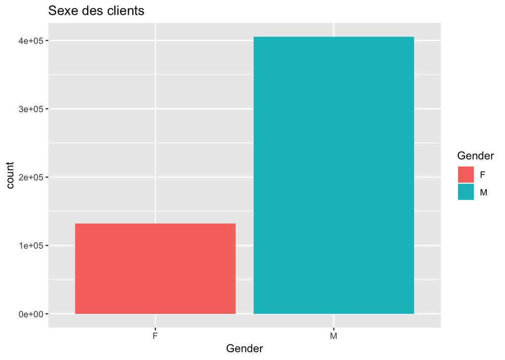

### Age

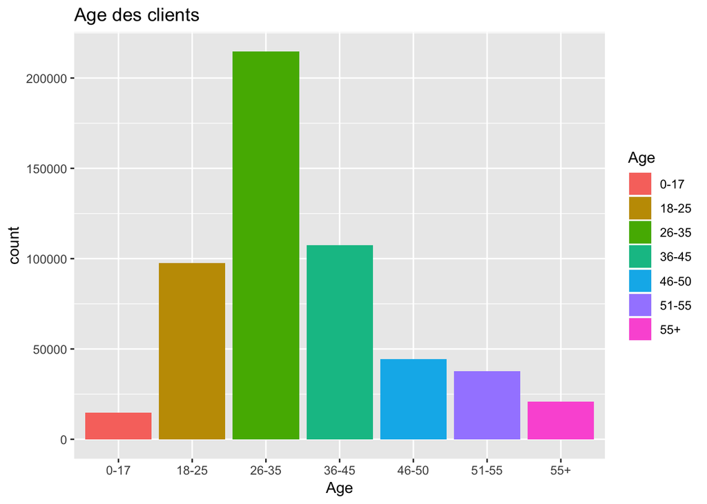

La distribution de l’age dans une population suit habituellement une loi normale. On observe ici que ce n’est pas le cas. Il apparait que la tranche d’âge des 26-35 effectue le plus d’achats lors du Black Friday.

### Métier

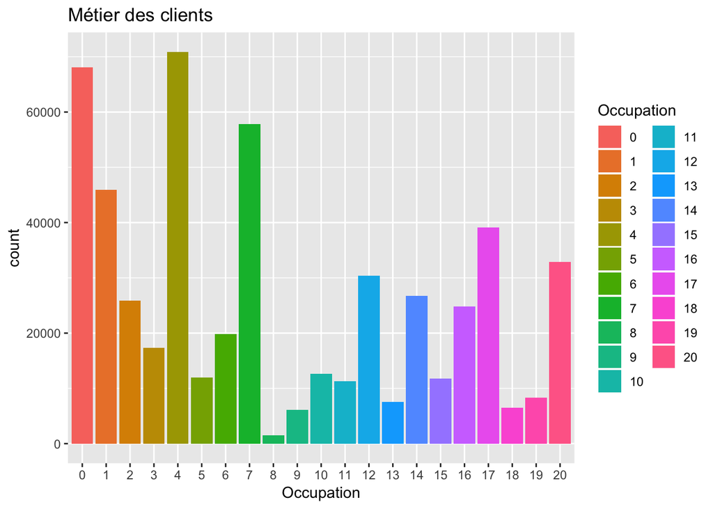

### Type de ville

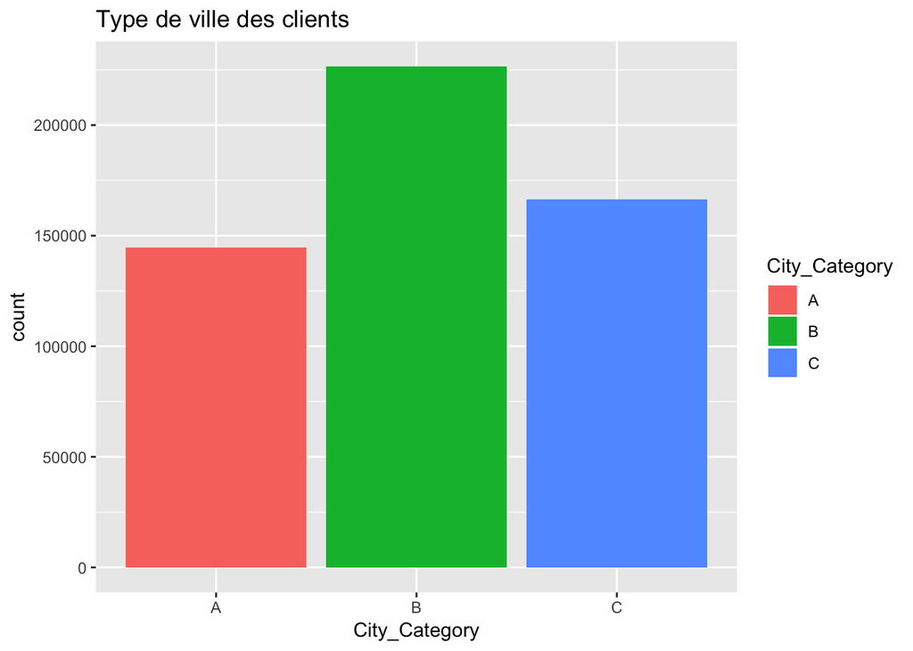

### Ancienneté dans la ville

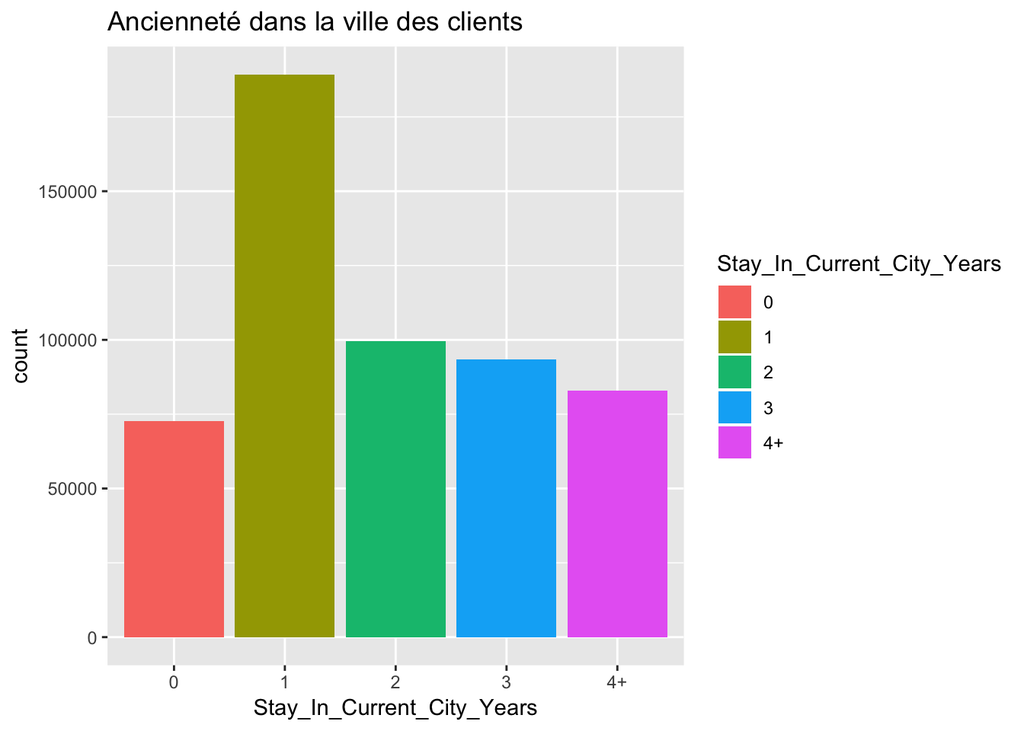

### Situation conjugale

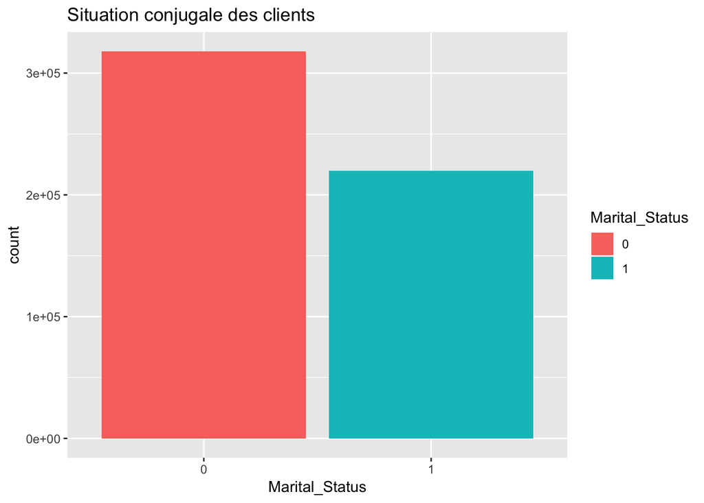

### Catégories des produits

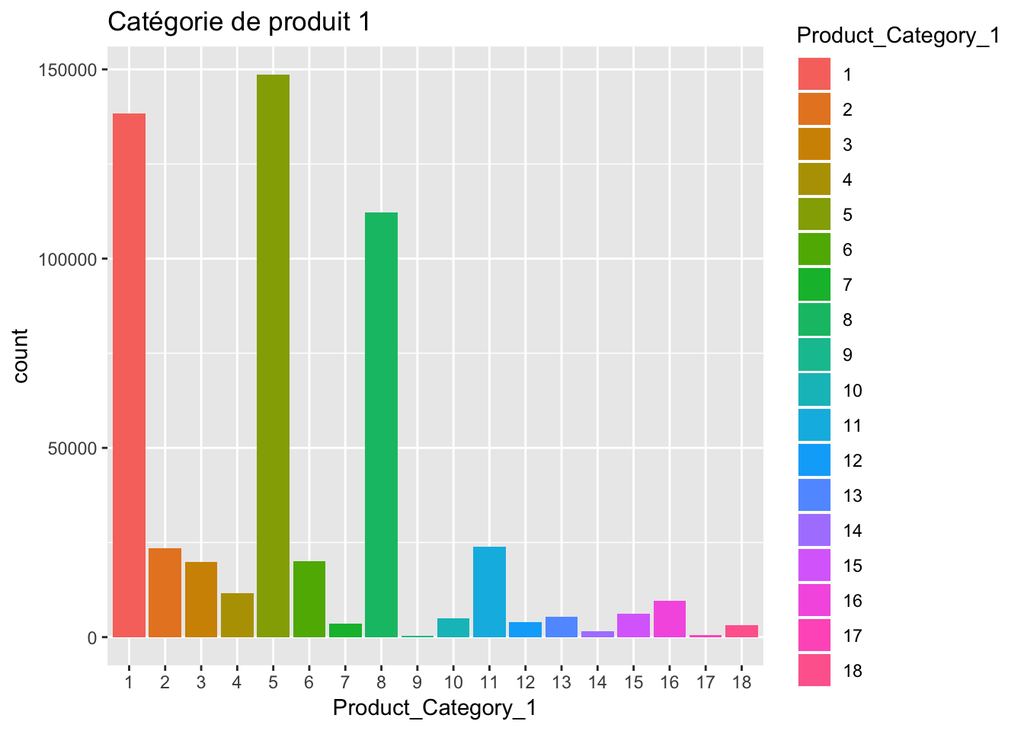

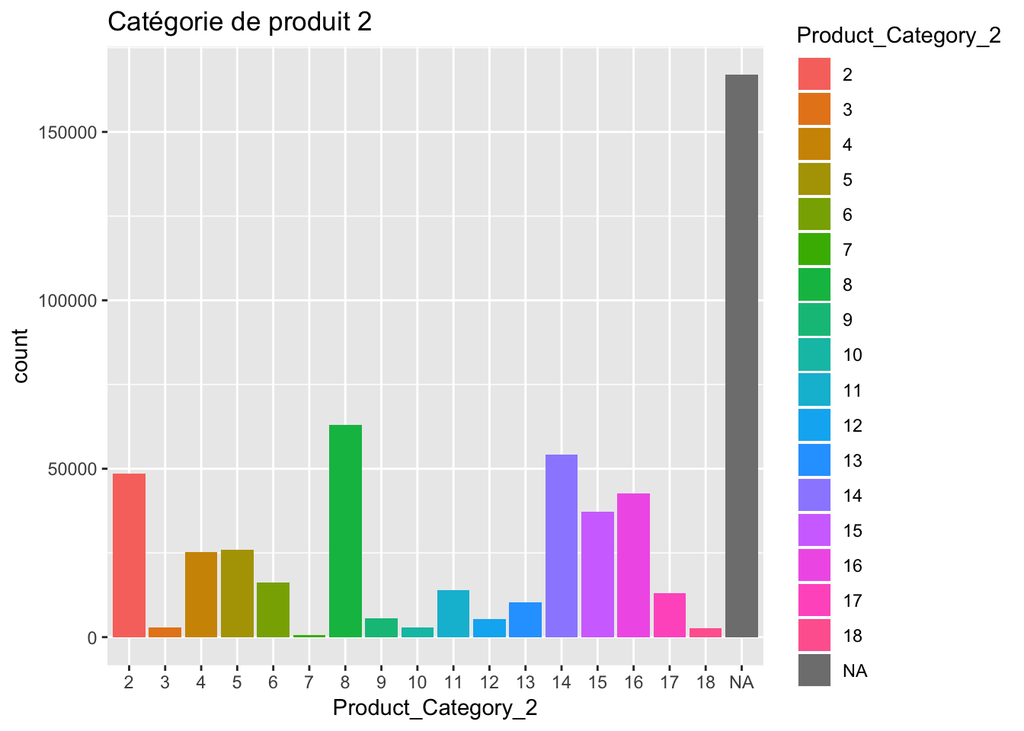

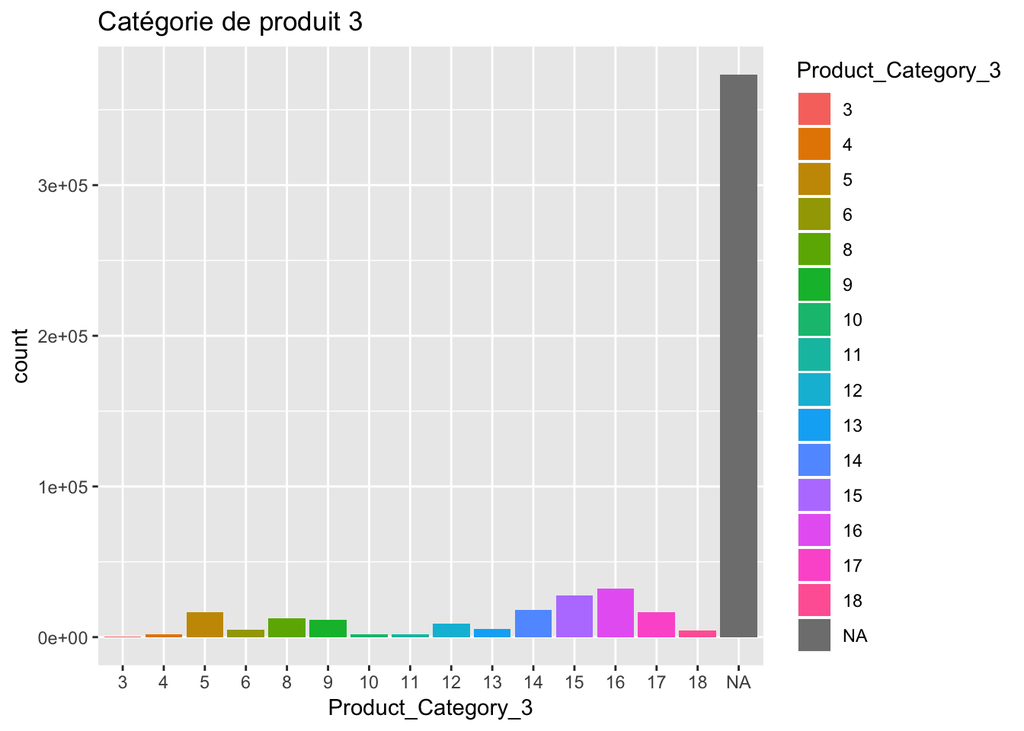

### Performance des produits

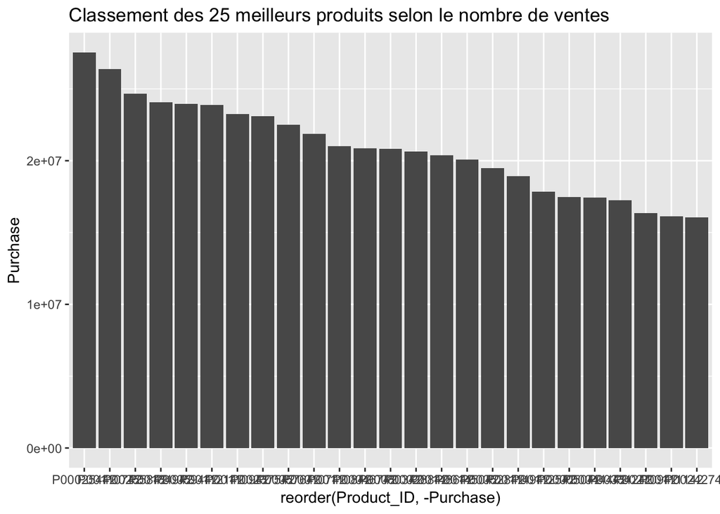

Pas de produit que se détache du reste (du moins dans les 25 premiers, il faut garder à l’esprit qu’il y en a +3000).

## Relations

Sociologie

- Age
- Métier
- Ancienneté dans la ville
- Marié, pas marié
- Sexe

=> Montant achat en fonction de l’age, métier, etc…

Commercial

- Performance des produit (via ID)
- Catégorie de produit qui se vendent le mieux

## Visu

```
##     User_ID            Product_ID     Gender        Age
##  Min.   :1000001   P00265242:  1858   F:132197   0-17 : 14707
##  1st Qu.:1001495   P00110742:  1591   M:405380   18-25: 97634
##  Median :1003031   P00025442:  1586              26-35:214690
##  Mean   :1002992   P00112142:  1539              36-45:107499
##  3rd Qu.:1004417   P00057642:  1430              46-50: 44526
##  Max.   :1006040   P00184942:  1424              51-55: 37618
##                    (Other)  :528149              55+  : 20903
##    Occupation     City_Category Stay_In_Current_City_Years Marital_Status
##  4      : 70862   A:144638      0 : 72725                  1:219760
##  0      : 68120   B:226493      1 :189192                  0:317817
##  7      : 57806   C:166446      2 : 99459
##  1      : 45971                 3 : 93312
##  17     : 39090                 4+: 82889
##  20     : 32910
##  (Other):222818
##  Product_Category_1 Product_Category_2 Product_Category_3    Purchase
##  Min.   : 1.000     Min.   : 2.00      Min.   : 3.0       Min.   :  185
##  1st Qu.: 1.000     1st Qu.: 5.00      1st Qu.: 9.0       1st Qu.: 5866
##  Median : 5.000     Median : 9.00      Median :14.0       Median : 8062
##  Mean   : 5.296     Mean   : 9.84      Mean   :12.7       Mean   : 9334
##  3rd Qu.: 8.000     3rd Qu.:15.00      3rd Qu.:16.0       3rd Qu.:12073
##  Max.   :18.000     Max.   :18.00      Max.   :18.0       Max.   :23961
##                     NA's   :166986     NA's   :373299
```

```
##   User_ID Product_ID Gender   Age Occupation City_Category
## 1 1000001  P00069042      F  0-17         10             A
## 2 1000001  P00248942      F  0-17         10             A
## 3 1000001  P00087842      F  0-17         10             A
## 4 1000001  P00085442      F  0-17         10             A
## 5 1000002  P00285442      M   55+         16             C
## 6 1000003  P00193542      M 26-35         15             A
##   Stay_In_Current_City_Years Marital_Status Product_Category_1
## 1                          2              0                  3
## 2                          2              0                  1
## 3                          2              0                 12
## 4                          2              0                 12
## 5                         4+              0                  8
## 6                          3              0                  1
##   Product_Category_2 Product_Category_3 Purchase
## 1                 NA                 NA     8370
## 2                  6                 14    15200
## 3                 NA                 NA     1422
## 4                 14                 NA     1057
## 5                 NA                 NA     7969
## 6                  2                 NA    15227
```

```
##     User_ID        Gender
##  Min.   :1000001   F:1666
##  1st Qu.:1001518   M:4225
##  Median :1003026
##  Mean   :1003025
##  3rd Qu.:1004532
##  Max.   :1006040
```

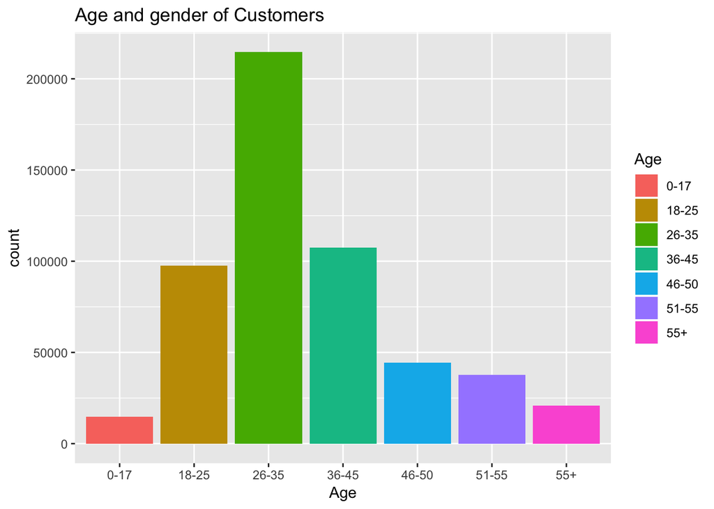

```
##     User_ID        Gender   City_Category    Age             x
##  Min.   :1000001   F:1666   A:1045        0-17 : 218   Min.   :   44108
##  1st Qu.:1001518   M:4225   B:1707        18-25:1069   1st Qu.:  234914
##  Median :1003026            C:3139        26-35:2053   Median :  512612
##  Mean   :1003025                          36-45:1167   Mean   :  851752
##  3rd Qu.:1004532                          46-50: 531   3rd Qu.: 1099005
##  Max.   :1006040                          51-55: 481   Max.   :10536783
##                                           55+  : 372
```

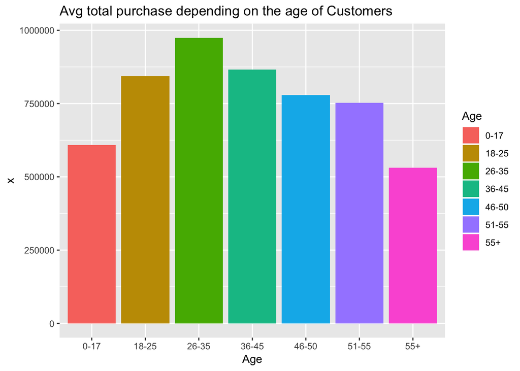

# Mesure de l’entropie et du gain d’entropie

```
##                        Age                     Gender
##                0.069374015                0.022694835
## Stay_In_Current_City_Years                 Occupation
##                0.013115811                0.091392940
##             Marital_Status              City_Category
##                0.007119339                0.019069753
```

Deux catégories importantes : Age et Occupation.